# Bellabeat Analysis and Visualizations

Aliza Haider

2025-07-30

## Setting up my environment

Notes: Setting up my R environment by loading the `tidyverse`, `ggplot2`, and `janitor` packages.

```r
library(tidyverse)
library(janitor)
```

## Importing the data

Notes: The`dailyActivity_merged.csv` file, containing cleaned daily activity and sleep data, was imported into R for analysis. Initial data cleaning (e.g., handling duplicates, formatting, and merging) was performed in Google Sheets prior to this step.

```r
daily_data <- read_csv(
  "dailyActivity_merged.csv",
  na = c("", "NA", "#N/A", "N/A")  # Treat these as missing values
)
```

## Data Preprocessing

Notes: The dataset was standardized using the clean_names() function to ensure consistent variable naming (only lowercase letters, numbers, and underscores).

```r
daily_data <- clean_names(daily_data)
head(daily_data)
```

```
## # A tibble: 6 × 20
##           id activity_date total_steps total_distance tracker_distance
##        <dbl> <chr>               <dbl>          <dbl>            <dbl>
## 1 1503960366 4/12/2016           13162           8.5              8.5
## 2 1503960366 4/13/2016           10735           6.97             6.97
## 3 1503960366 4/14/2016           10460           6.74             6.74
## 4 1503960366 4/15/2016            9762           6.28             6.28
## 5 1503960366 4/16/2016           12669           8.16             8.16
## 6 1503960366 4/17/2016            9705           6.48             6.48
## # ℹ 15 more variables: logged_activities_distance <dbl>,
## #   very_active_distance <dbl>, moderately_active_distance <dbl>,
## #   light_active_distance <dbl>, sedentary_active_distance <dbl>,
## #   very_active_minutes <dbl>, fairly_active_minutes <dbl>,
## #   lightly_active_minutes <dbl>, sedentary_minutes <dbl>, calories <dbl>,
## #   total_sleep_records <dbl>, total_minutes_asleep <dbl>,
## #   total_time_in_bed <dbl>, sleep_efficiency <dbl>, day_type <chr>
```

## Data Analysis

A subset of relevant columns — id, activity_date, total_steps, total_minutes_asleep, total_time_in_bed, and sleep_efficiency — was selected to create a clean sleep_data dataset, excluding any rows with missing values.

```r
# Select required columns and drop rows with NA for sleep_data
sleep_data <- daily_data %>%
  select(id, activity_date, total_steps, total_minutes_asleep, total_time_in_bed, sleep_efficiency) %>%
  drop_na()

# Check results
sum(is.na(sleep_data))  # Verify no NAs in output
```

```
## [1] 0
```

```r
# View the data
head(sleep_data)
```

```
## # A tibble: 6 × 6
##           id activity_date total_steps total_minutes_asleep total_time_in_bed
##        <dbl> <chr>               <dbl>                <dbl>             <dbl>
## 1 1503960366 4/12/2016           13162                  327               346
## 2 1503960366 4/13/2016           10735                  384               407
## 3 1503960366 4/15/2016            9762                  412               442
## 4 1503960366 4/16/2016           12669                  340               367
## 5 1503960366 4/17/2016            9705                  700               712
## 6 1503960366 4/19/2016           15506                  304               320
## # ℹ 1 more variable: sleep_efficiency <dbl>
```

To investigate the connection between physical activity and sleep, a Pearson correlation test was conducted between total daily steps and minutes asleep.

```r
# Assess linear relationship between daily steps and minutes asleep using Pearson correlation test
cor_test_result <- cor.test(
  x = sleep_data$total_steps,
  y = sleep_data$total_minutes_asleep,
  method = "pearson"
)

# Print results
print(cor_test_result)
```

```
##
##  Pearson's product-moment correlation
##
## data:  sleep_data$total_steps and sleep_data$total_minutes_asleep
## t = -3.9164, df = 408, p-value = 0.0001054
## alternative hypothesis: true correlation is not equal to 0
## 95 percent confidence interval:
##  -0.28199288 -0.09525253
## sample estimates:
##        cor
## -0.1903439
```

Additionally, users were grouped into three activity levels (Low, Moderate, High) based on step counts, and average sleep duration was compared across these groups.

```r
# Categorize total_steps into activity groups, then calculate average sleep duration for each group
sleep_data %>%
  mutate(activity_group = cut(
    total_steps,
    breaks = c(0, 5000, 10000, Inf),
    labels = c("Low", "Moderate", "High"))
  ) %>%
  group_by(activity_group) %>%
  summarise(avg_sleep = mean(total_minutes_asleep))
```

```
## # A tibble: 3 × 2
##   activity_group avg_sleep
##   <fct>              <dbl>
## 1 Low                 454.
## 2 Moderate            422.
## 3 High                396.
```

Users were classified into four behavior-based segments using daily step count, sleep duration, and sedentary minutes:

- Sedentary (more than 720 sedentary minutes),
- Active Sleeper (over 8000 steps and more than 7 hours of sleep),
- Active (over 8000 steps but less than 7 hours sleep), and
- Moderate (all others).

```r
# Categorize users on the basis of steps, sleep, and sedentary minutes
analysis_data <- daily_data %>%
  mutate(
    activity_level = case_when(
      sedentary_minutes > 720 ~ "Sedentary",
      total_steps > 8000 & total_minutes_asleep > 420 ~ "Active Sleeper",
      total_steps > 8000 ~ "Active",
      TRUE ~ "Moderate"
    )
  )

head(analysis_data)
```

```
## # A tibble: 6 × 21
##           id activity_date total_steps total_distance tracker_distance
##        <dbl> <chr>               <dbl>          <dbl>            <dbl>
## 1 1503960366 4/12/2016           13162           8.5              8.5
## 2 1503960366 4/13/2016           10735           6.97             6.97
## 3 1503960366 4/14/2016           10460           6.74             6.74
## 4 1503960366 4/15/2016            9762           6.28             6.28
## 5 1503960366 4/16/2016           12669           8.16             8.16
## 6 1503960366 4/17/2016            9705           6.48             6.48
## # ℹ 16 more variables: logged_activities_distance <dbl>,
## #   very_active_distance <dbl>, moderately_active_distance <dbl>,
## #   light_active_distance <dbl>, sedentary_active_distance <dbl>,
## #   very_active_minutes <dbl>, fairly_active_minutes <dbl>,
## #   lightly_active_minutes <dbl>, sedentary_minutes <dbl>, calories <dbl>,
## #   total_sleep_records <dbl>, total_minutes_asleep <dbl>,
## #   total_time_in_bed <dbl>, sleep_efficiency <dbl>, day_type <chr>, …
```

```r
# Count users in each activity_level and calculate percent
segment_counts <- analysis_data %>%
  count(activity_level) %>%
  arrange(desc(activity_level)) %>%
  mutate(percent = n/sum(n),
         ypos = cumsum(percent) - 0.5 * percent)
```

A new dataset, summary_data, was created by grouping users based on their activity_level and calculating the average calories burned within each group.

```r
# Create a summary_data with one row per activity_level and their average calories
summary_data <- analysis_data %>%
  group_by(activity_level) %>%
  summarise(avg_calories = mean(calories, na.rm = TRUE))

head(summary_data)
```

```
## # A tibble: 4 × 2
##   activity_level avg_calories
##   <chr>                 <dbl>
## 1 Active                2632.
## 2 Active Sleeper        2654.
## 3 Moderate              1776.
## 4 Sedentary             2304.
```

## Visualizations

Here, we will go through a series of visualizations.

### Activity-Sleep Relationships

#### Correlation: Steps vs. Sleep Duration

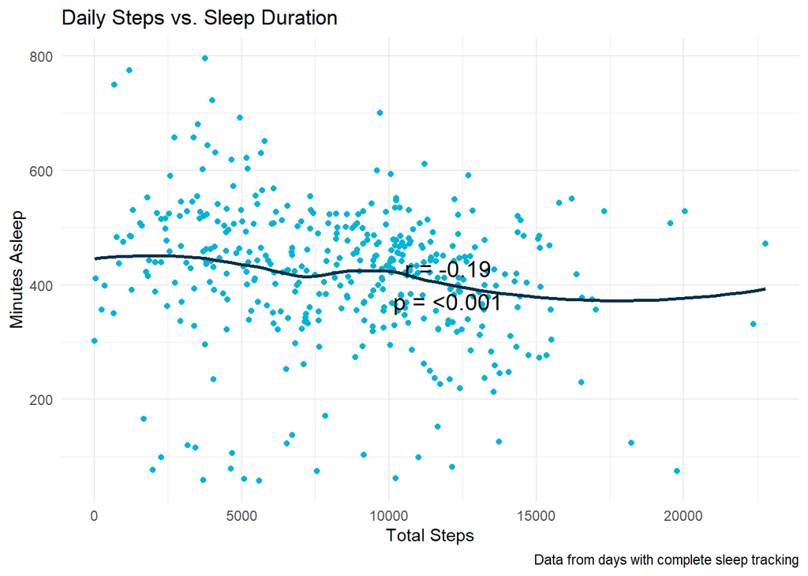

```r
# Plot Steps vs Sleep duration
ggplot(data = sleep_data, aes(x = total_steps, y = total_minutes_asleep)) +
  geom_point(colour = "#00b4d8") +
  geom_smooth(method = "loess", colour = "#003049", se = FALSE) +
  annotate("text", x = 12000, y = 400, label = paste0("r = ", round(cor_test_result$estimate, 2),
                                                      "\np = ", format.pval(cor_test_result$p.value, digits = 3, eps = .001)),
           size = 5) +
  labs(
    title = "Daily Steps vs. Sleep Duration",
    x = "Total Steps",
    y = "Minutes Asleep",
    caption = "Data from days with complete sleep tracking"
  ) +
  theme_minimal()
```

#### Sleep Efficiency

A histogram was plotted to illustrate the distribution of sleep efficiency among users, calculated as the ratio of total minutes asleep to total time in bed. The average sleep efficiency is highlighted with a dashed vertical line and annotated on the plot, providing a clear reference point. The distribution shows how users vary in sleep quality, which can help identify patterns or segments for targeted wellness interventions.

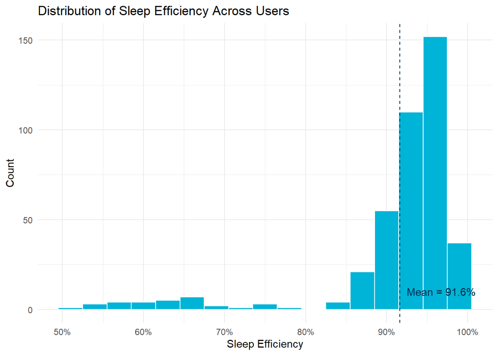

```r
# Calculate mean sleep efficiency
mean_val <- mean(sleep_data$sleep_efficiency, na.rm = TRUE)

# Plot Sleep Efficiency Histogram
ggplot(data = sleep_data, aes(x = sleep_efficiency)) +
  geom_histogram(binwidth = 0.03, fill = "#00b4d8", colour = "white") +
  scale_x_continuous(labels = scales::percent) +
  geom_vline(xintercept = mean(sleep_data$sleep_efficiency, na.rm = TRUE),
             color = "#003049", linetype = "dashed") +
  annotate("text", x = mean_val, y = 10, label = paste0("Mean = ", round(mean_val * 100, 1), "%"),
           color = "#003049", hjust = -0.1) +
  labs(
    title = "Distribution of Sleep Efficiency Across Users",
    x = "Sleep Efficiency",
    y = "Count"
  ) +
  theme_minimal()
```

### User Segments by Behavior (*For personalized marketing*)

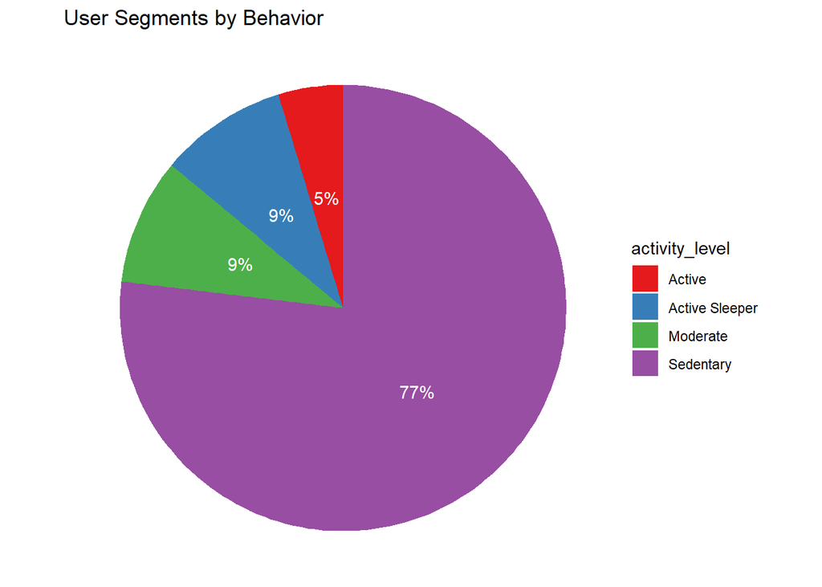

```r
# Plot a donut chart showing segment proportions
ggplot(segment_counts, aes(x = 1, y = percent, fill = activity_level)) +
  geom_bar(stat = "identity", width = 1) +
  coord_polar("y") +
  scale_fill_brewer(palette = "Set1") +
  xlim(0.5, 1.5) +
  geom_text(aes(y = ypos, label = paste0(round(percent * 100), "%")), color = "white") +
  theme_void() +
  labs(
    title = "User Segments by Behavior",
  )
```

### Time-Based Trends

This boxplot compares users’ total daily steps on weekdays versus weekends to identify behavioral differences across the week. The visualization reveals trends in activity patterns throughout the week. Understanding these variations can inform time-targeted engagement strategies and personalized wellness recommendations.

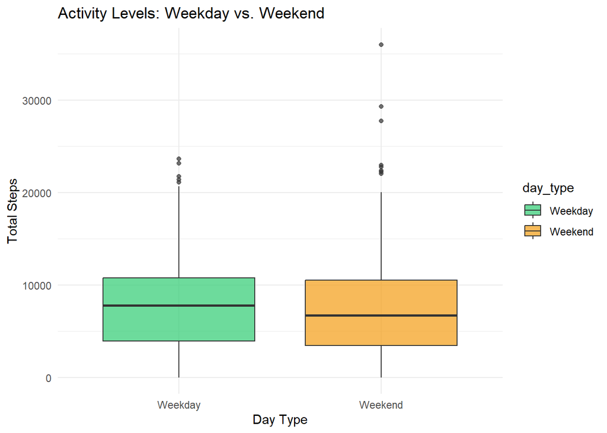

```r
# Plot Weekday vs. Weekend Activity
ggplot(analysis_data, aes(x = day_type, y = total_steps, fill = day_type)) +
  geom_boxplot(alpha = 0.7) +
  scale_fill_manual(values = c("#2ecc71", "#f39c12")) +
  labs(
    title = "Activity Levels: Weekday vs. Weekend",
    x = "Day Type",
    y = "Total Steps"
  ) +
  theme_minimal()
```

### Calories and Activity

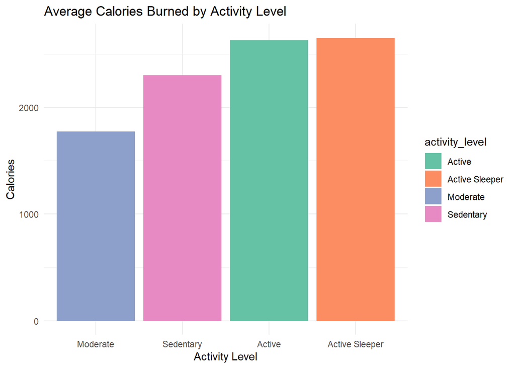

```r
# Plot Calories burned by Activity level
ggplot(summary_data, aes(x = reorder(activity_level, avg_calories), y = avg_calories, fill = activity_level)) +
  geom_col() +
  scale_fill_brewer(palette = "Set2") +
  labs(
    title = "Average Calories Burned by Activity Level",
    x = "Activity Level",
    y = "Calories"
  ) +
  theme_minimal()
```